# Canadian *Malus* CWR Species Distribution Modeling

To do this we can compare the density of covariates from occurrence points and background points. I like to visualize this density using Kernel Density Plots. This plot allows you to visualize three dimensions, in this case two of the bioclimatic predictor variables, and the density of points sampled (pseudo-probability). We will build two separate plots to visualize the density of occurrence points and of background points.

First we will create new data frames for each of the climatic variables (in this case mean annual temperature, and mean annual precipitation), so that we can plot them below.

```r
# Predictor Kernel Density Plots
# It is helpful to visualize two predictors pairs of
# Presence points and background points


cor_occ.temp <- cor_sdmData %>% filter(cor_pb == 1) %>% # Presence points
  dplyr::select(wc2.1_2.5m_bio_1) %>% # Mean annual temp
  drop_na() %>%
  unlist()
cor_bg.temp <- cor_sdmData %>% filter(cor_pb == 0) %>% # Background points
  dplyr::select(wc2.1_2.5m_bio_1) %>% # Mean annual temp
  drop_na() %>%
  unlist()

cor_occ.perc <- cor_sdmData %>% filter(cor_pb == 1) %>% # Presence points
  dplyr::select(wc2.1_2.5m_bio_12) %>% # Annual precipitation
  drop_na() %>%
  unlist()

cor_bg.perc <- cor_sdmData %>% filter(cor_pb == 0) %>% # Background points
  dplyr::select(wc2.1_2.5m_bio_12) %>% # Annual precipitation
  drop_na() %>%
  unlist()
```

Now that all the data is prepared, we will build the build the Kernel bivariate grid, using the function `MASS::kde2d`. This function needs three values, the x coordinate = temperature values, y coordinate = precipitation values, and the z coordinate is density of occurrence (pseudo-probability).

```r
cor_occ.3d <- kde2d(cor_occ.temp, cor_occ.perc)
cor_bg.3d <- kde2d(cor_bg.temp, cor_bg.perc)
```

And plot the results using the package `plot_ly`. These build interactive 3D plots, and in this case can be used to visualize the Kernel plots.

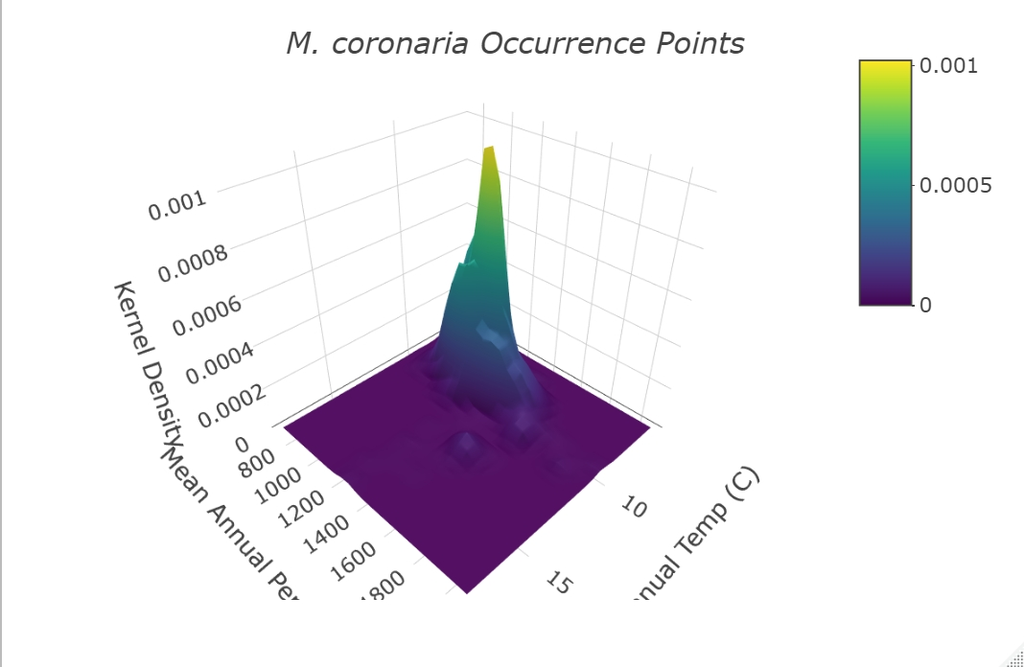

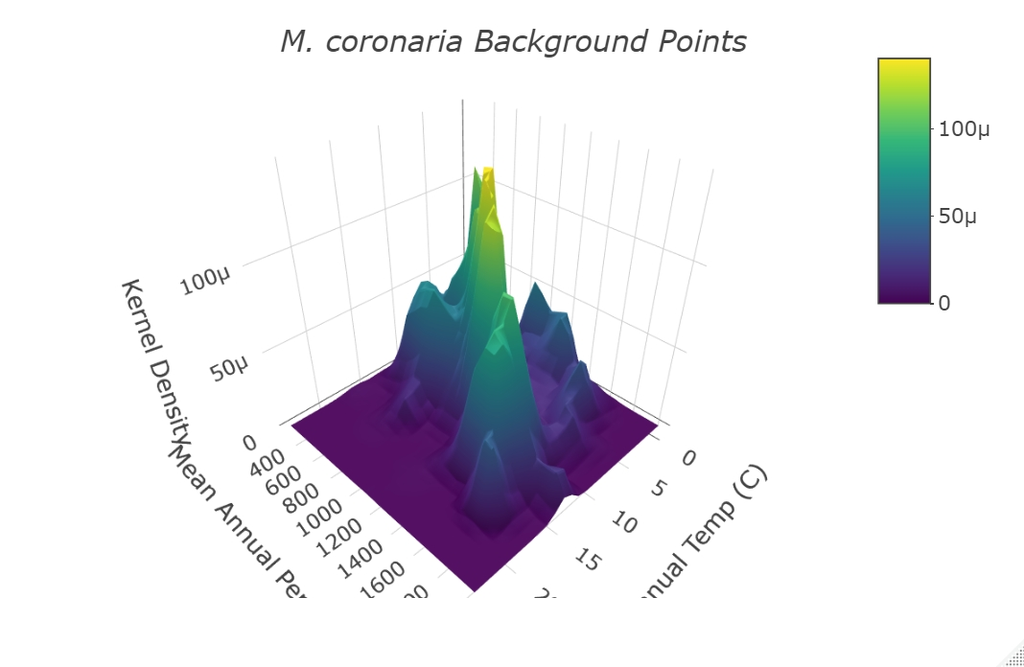

```r
plot_cor.occ_3d <- plot_ly(x=cor_occ.3d$x, y=cor_occ.3d$y, z=cor_occ.3d$z) %>%
  add_surface() %>%
  layout(scene = list(xaxis = list(title = 'Mean Annual Temp (C)', autotick = F, nticks = 5, tickvals = list(0,5,10,15,20)),
                      yaxis = list(title = 'Mean Annual Percip. (mm)', tick0=0, tick1=2000, dtick=200),
                      zaxis = list(title = 'Kernel Density', tick0=0, tick1=0.001, dtick=0.0002)),
         title = list(text = "<i>M. coronaria<i> Occurrence Points",
                      y = 0.95, x = 0.5,
                      xanchor = 'center',
                      yanchor = 'top'))

plot_cor.occ_3d # run to view

plot_cor.bg_3d <- plot_ly(x=cor_bg.3d$x, y=cor_bg.3d$y, z=cor_bg.3d$z) %>%
  add_surface() %>%
  layout(scene = list(xaxis = list(title = 'Mean Annual Temp (C)', tick0=0, tick1=20, dtick=5),
                      yaxis = list(title = 'Mean Annual Percip. (mm)', tick0=0, tick1=2000, dtick=200),
                      zaxis = list(title = 'Kernel Density')),
         title = list(text = "<i>M. coronaria<i> Background Points",
                      y = 0.95, x = 0.5,
                      xanchor = 'center',
                      yanchor = 'top'))

plot_cor.bg_3d
```

In this example I only visualize two of the 19 different bioclimatic variables. You may choose to visualize more for your own purposes. Remember this is only a visual comparison, but is valuable for understanding what the model is ‘seeing’ - of course it is using multidimensional space of all covariates, not just the two here.

## Species Distribution Modeling and Climate Projections

So now have all we need (almost) to build the SDMs, finally. We have the presence (occurrence) points, and background points. We also have the climatic predictor rasters (WorldClim bioclimatic variables). What we don’t have is the **future bioclimatic data**, which we will use with the results of the SDM to make predictions about future suitable habitat, under different climatic scenarios.

```r
library(tidyverse) # Grammar and data management
library(terra)# Spatial Data package
library(predicts) # SDM package
library(geodata) # basemaps
library(rJava) # MaxEnt models are dependant on JDK
library(ENMeval) # Another modeling package, useful for data partitioning (Checkerboarding)
library(raster) # RasterStack dependancy (a now deprecated function)
library(ecospat) # Useful spatial ecology tools
library(parallel) # speed up computation by running in parallel
library(doParallel) # added functionality to parallel
```

Let’s start by loading in the thinned occurrence points and background points, along with some base maps of Canada, USA, and Mexico. (Note: In the end I decided not to use these boundaries for plotting, but you may want to for your purposes so I left the chunk here).

```r
# Download/load basemaps
us_map <- gadm(country = 'USA', level = 1, resolution = 2,
               path = "../occ_data/base_maps") #USA basemap w. States

ca_map <- gadm(country = 'CA', level = 1, resolution = 2,
               path = '../occ_data/base_maps') # Canada basemap w. Provinces

mex_map <-gadm(country = 'MX', level = 1, resolution = 2,
               path = '../occ_data/base_maps') # Mexico basemap w. States

canUSMex_map <- rbind(us_map, ca_map, mex_map) # Combine Mexico, US and Canada vector map


NA_ext <- ext(-180, -30, 18, 85) # Set spatial extent of analyis to NA in Western Hemisphere

canUSMex_map <- crop(canUSMex_map, NA_ext) # crop to Western Hemisphere

plot(canUSMex_map) # plot basemap
```

We are also going to load a shape file that outlines the Great Lakes. This helps to make the figures more pretty, and we can also use the vector layer to mask the predictor layers so that no predictions are made over the Great Lakes (Malus cannot swim…). You can download the shape files from the url below.

```r
# Great Lakes shapefiles for making pretty maps
# Shape files downloaded from the USGS (https://www.sciencebase.gov/catalog/item/530f8a0ee4b0e7e46bd300dd)
great_lakes <- vect('C:/Users/terre/Documents/Acadia/Malus Project/maps/great lakes/combined great lakes/')
```

Now lets download the future bioclimatic data. For this we will need to specify a few additional arguments then before when downloading the historical climate data. We will again use the `geodata` package, but instead of `worldclim_global` we will use `cmip6_world`.

This function will download data for projected future climates from Coupled Model Intercomparison Project Phase 6 (CMIP6) generated from Global Climate Models (GCMs). CMIP6 projections are based on the Shared Socio-economic Pathway (SSP) scenarios, included in the Intergovernmental Panel on Climate Change (IPCC) Assessment Report (AR6).

In There are six different SSPs, four of which are available through `geodata`, “126”, “245”, “370” and “585”; for SSP1-2.6, SSP2-4.5, SSP3-7.0, SSP5-8.5. This is also available for three time periods: “2021-2040”, “2041-2060”, and “2061-2080”; or early century (2030), mid century (2050) and late century (2070). In this workflow I will model all three timeframes, and I chose two SSPs, SSP2-4.5 and SSP5-8.5. The former repersents a ‘middle of the road’ scenario with high climate adaptation, low climate mitigation; and the later is a ‘worst case’ or ‘bussiness as usual’ scenario where the global development continues down a unsustainable route with increased fossil fuel reliance. It is worth noting that SSP5-8.5 is the current tracking scenario: https://news.stanford.edu/2023/01/30/ai-predicts-global-warming-will-exceed-1-5-degrees-2030s/.

The final decision to make is which CMIP6 climate model you are going to choose. There are several models available through `geodata`, all of which have their individual strengths and weaknesses. For the purposes of this study, as I am primary concerned with *Malus* habitat in Canada, I chose to use the Canadian Earth System Model version 5 (CanESM5). This model is still a global model, but it is most commonly employed for climate research in Canada. Read more here: https://gmd.copernicus.org/articles/12/4823/2019/gmd-12-4823-2019.html

**NOTE:** Climate projections, are just that, *projections*. These models are useful, but can be flawed for a host of reasons. Recently it has come to the attention of climate modelers that many of the models included in CMIP6 are ‘too hot’, meaning the rates of warming may be too high, although this is not true for every region. Read more here: https://www.science.org/content/article/use-too-hot-climate-models-exaggerates-impacts-global-warming.

```r
# Historical climate 1970-2000
wclim <- geodata::worldclim_global(var = 'bio',
                                   res = 2.5,
                                   version = '2.1',
                                   path = "../wclim_data/") %>%
  crop(NA_ext) %>% #crop raster to NA
  mask(great_lakes, inverse = T) # cut out the great lakes

# SSP (Shared social-economic pathway) 2.45
# middle of the road projection, high climate adaptation, low climate mitigation
ssp245_2030 <- cmip6_world(model = "CanESM5",
                           ssp = "245",
                           time = "2021-2040",
                           var = "bioc",
                           res = 2.5,
                           path = "../wclim_data/") %>%
  crop(NA_ext) %>% #crop raster to NA
  mask(great_lakes, inverse = T) # cut out the great lakes

ssp245_2050 <- cmip6_world(model = "CanESM5",
                           ssp = "245",
                           time = "2041-2060",
                           var = "bioc",
                           res = 2.5,
                           path = "../wclim_data/") %>%
  crop(NA_ext) %>% #crop raster to NA
  mask(great_lakes, inverse = T) # cut out the great lakes

ssp245_2070 <- cmip6_world(model = "CanESM5",
                           ssp = "245",
                           time = "2061-2080",
                           var = "bioc",
                           res = 2.5,
                           path = "../wclim_data/") %>%
  crop(NA_ext) %>% #crop raster to NA
  mask(great_lakes, inverse = T) # cut out the great lakes

# SPP 5.85
# low regard for enviromental sustainability, increased fossil fuel reliance, this is the current tracking projection
ssp585_2030 <- cmip6_world(model = "CanESM5",
                           ssp = "585",
                           time = "2021-2040",
                           var = "bioc",
                           res = 2.5,
                           path = "../wclim_data/") %>%
  crop(NA_ext) %>% #crop raster to NA
  mask(great_lakes, inverse = T) # cut out the great lakes

ssp585_2050 <- cmip6_world(model = "CanESM5",
                           ssp = "585",
                           time = "2041-2060",
                           var = "bioc",
                           res = 2.5,
                           path = "../wclim_data/") %>%
  crop(NA_ext) %>% #crop raster to NA
  mask(great_lakes, inverse = T) # cut out the great lakes

ssp585_2070 <- cmip6_world(model = "CanESM5",
                           ssp = "585",
                           time = "2061-2080",
                           var = "bioc",
                           res = 2.5,
                           path = "../wclim_data/")%>%
  crop(NA_ext) %>% #crop raster to NA
  mask(great_lakes, inverse = T) # cut out the great lakes
```

**NOTE:** Just like with the previous climate data, DO NOT push these large files to a github repo due to the size of the files.

Now that we have the future climate data we need to do a bit more prep work to get ready for the SDMs. First we should load in the cropped climate rasters from the background sampling script. I am doing this so I can visualize a spatial sampling method called checkerboarding (more details to come below).

```r
# These Rasters are useful for sampling spatial checkerboards
# and making habitat suitability predictions (Historical and under future SSPs climate scenarios)

setwd('../wclim_data')
# Historical (1970-2000)
wclim_cor <- readRDS(file = 'wclim_cor.Rdata')
wclim_cor_stack <- raster::stack(wclim_cor) # covert SpatRaster to RasterStack for dependency in ENMeval checkboarding

wclim_fus <- readRDS(file = 'wclim_fus.Rdata')
wclim_fus_stack <- raster::stack(wclim_fus) # covert SpatRaster to RasterStack for dependency in ENMeval checkboarding
```

**NOTE:** The `stack` function is from the deprecated package `raster` so it may not work in future versions of `ENMeval` (package for checkerboarding and SDM). Similar function from the more up to data `terra` package is `terra::c`, which can be used to combine SpatRasters, but does not have the required `RasterStack` object signature.

Then for ease of making predictions downsteam we will extract the names of each bioclimatic raster layer so that we can rename the layers from the projected climates. This is so that when making predictions using our SDM downstearm the names correspond.

```r
climate_predictors <- names(wclim_cor) # extract climate predictor names, to rename layers in the rasters below
# This is important to do for making predictions once the SDMs have been made on future climate data
# Note that the names of the layers still correspond to the same environmental variables

# Future SSPs
# Do not need to create RasterStacks
# SSP 245
names(ssp245_2030) <- climate_predictors #rename raster layers for downsteam analysis
names(ssp245_2050) <- climate_predictors
names(ssp245_2070) <- climate_predictors

# SSP 585
names(ssp585_2030) <- climate_predictors #rename raster layers for downsteam analysis
names(ssp585_2050) <- climate_predictors
names(ssp585_2070) <- climate_predictors
```

So now we have all our data prepped and its time to start getting things sorted for the SDM. In the next few pieces of code I am going to show you how to manually partition data into training and testing groups. There are several reasons for doing this, including and most importantly evaluating the performance and generalization of the model. This is called **cross-validation**, whereby the species occurrence data is partitioned into *training* data that gets inputted into the model, and *testing* data that is withheld and used to evaluate how well the trained model fits the ‘new’ testing occurrences. There are several different ways to partition data, all of which have pros/cons.

The simplest method is k-fold random, where data is equally binned into groups (‘folds’). However, this can be flawed as can preserve bias in the training and testing data. It is preferred to use **spatial partitioning** to reduce spatial autocorrelation preserve spatial heterogeneity, which can help reduce model overfitting. This creates partitions that are much more ecologically relevant so that the model can learn how the species is spatially organized, which in turn makes the predictions of the model more generalizable for future climate predictions.

There are several different methods to spatially partition occurrence data. A common approach is to overlay a square grids and take a checkerboard pattern of occurrences, where occurrences are partitioned depending on what square they fall in. The method I will demonstrate will complete 4-fold cross validation, where four partitions are taken - three will be used for training and one for testing. As I mentioned I will show you how to do this manually, but the MaxEnt function we will use later will do this partitioning for us, as well are cycle through and withhold each group.

Read more about spatial partitioning and checkerboarding in the following two articles.

Radosavljevic, A., & Anderson, R. P. (2014). Making better Maxent models of species distributions: complexity, overfitting and evaluation. Journal of biogeography, 41(4), 629-643. https://doi.org/10.1111/jbi.12227.

Muscarella, R., Galante, P. J., Soley‐Guardia, M., Boria, R. A., Kass, J. M., Uriarte, M., & Anderson, R. P. (2014). ENM eval: An R package for conducting spatially independent evaluations and estimating optimal model complexity for Maxent ecological niche models. Methods in ecology and evolution, 5(11), 1198-1205. https://doi.org/10.1111/2041-210X.12261.

Let’s get started with the partitions.

```r
# Spatial partitioning preparation

occ_cor_coords <- as.data.frame(geom(occThin_cor)[,3:4]) # extract longitude, lattitude from occurence points
bg_cor_coords <- as.data.frame(geom(cor_bg_vec)[,3:4]) # extract longitude, lattitude from background points

occ_fus_coords <- as.data.frame(geom(occThin_fus)[,3:4]) # extract longitude, lattitude from occurence points
bg_fus_coords <- as.data.frame(geom(fus_bg_vec)[,3:4]) # extract longitude, lattitude from background points
```

The `geom` function will get the geometry of the occurrences from the SpatVectors and store them in data frames.

```r
# Spatial Checkerboard partitioning of occurrence and background points cross-fold validation
set.seed(1337)

agg_factor <- c(9,9) # this defines how many adjacent cells are aggregated into the same checkboard 'sqaure'
# I visually tested different aggregations and found 9,9 was the best fit given the spatial extent
```

**NOTE:** We are using the `get.checkerboard2` function to get the 4-fold cross validation. This function is convenient but there is no reason why you could not do more partitions if you wanted to.

There are four required arguments: **1.** the species occurrences coordinates, **2.** background point coordinates, **3.** a predictor `RasterStack` that is cropped to the extent of the background, and **4.** the above defined aggregation factor.

Then we can use the `evalplot.grps` function to visualize the partitions.

```r
cor_cb <- get.checkerboard2(occs = occ_cor_coords,
                            bg = bg_cor_coords,
                            envs = wclim_cor_stack,
                            aggregation.factor = agg_factor
                            )

evalplot.grps(pts = occ_cor_coords, pts.grp = cor_cb$occs.grp, envs = wclim_cor_stack, pts.size = .75) # plot the checkerboard partitions of occurrence points
evalplot.grps(pts = bg_cor_coords, pts.grp = cor_cb$bg.grp, envs = wclim_cor_stack, pts.size = .75) # plot the checkerboard partitions of occurrence bg points
# background points may return an error if the checkboard sampling, this can happen due to the aggregation factor removing some obs
# It is fine as we do not need to visualize groups. If you want to, must remove the difference in observations.
```

First lets look at the species occurrence partitions. But, it is hard to see the checkerboard pattern.

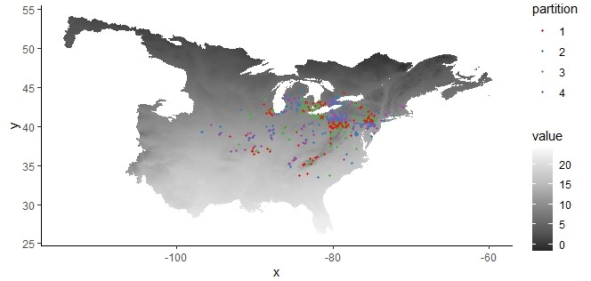

Now let’s look at the background points. As you can see the checkerboarding is much clearer. I also show how adjusting the aggregation factor changes the scale at which the partitions are taken from.

**3,3** aggregation

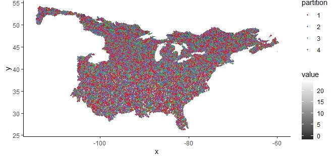

**6,6** aggregation

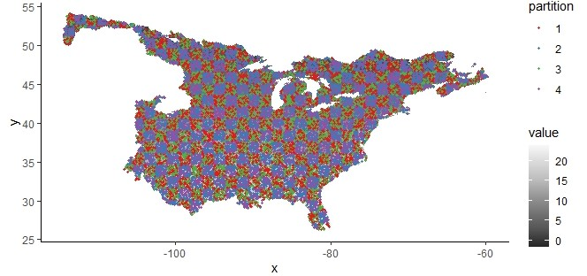

**9,9** aggregation, which I chose to use!

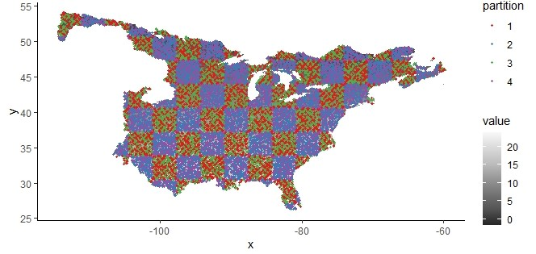

**12,12** aggregation

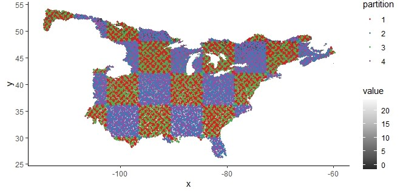

Okay, now that we have played around with the understanding how background point sampling works lets dive into developing our MaxEnt model. We are going to use **parallel processing**, to utilize multiple processors (CPUs) simultaneously. This will increase the amount of available memory and significantly decrease the computational time. If you are using a Windows computer (like me), then you only have one type of parallel processing available to you, known as ‘socket’ clusters. Read more here: https://www.r-bloggers.com/2019/06/parallel-r-socket-or-fork/#:~:text=As%20a%20result%2C%20it%20runs,40%25%20faster%20than%20the%20socket.

First let’s take a look at the code chunk and then I will break each argument down.

```r
# Build Species Distribution Model using MaxEnt from the <ENMeval> package

# Run prediction in a parallel using 'socket' clusters to help speed up computation
# <ENMeval> implements parallel functions natively
# But load <parallel> library for additional functions like <decectCores()>
cn <- detectCores(logical = F) # logical = F, is number of physical RAM cores in your computer
set.seed(1337)

cor_maxent <- ENMevaluate(occ = occ_cor_coords, # occurrence records
                            envs = wclim_cor, # environment from background training area
                            n.bg = 20000, # 20000 bg points
                            tune.args =
                              list(rm = seq(0.5, 8, 0.5),
                                   fc = c("L", "LQ", "H",
                                          "LQH", "LQHP", "LQHPT")),
                            partition.settings =
                              list(aggregation.factor = c(9, 9),  gridSampleN = 20000), # 9,9 agg
                            partitions = 'checkerboard2',
                            parallel = TRUE,
                            numCores = cn - 1, # leave one core available for other apps
                            parallelType = "doParallel", # use doParrallel on Windows - socket cluster
                            algorithm = 'maxent.jar')
```

**NOTE:** The `cn` object is the number of physical CPUs your computer has. The function `detectCores` requires that you load the `parallel` library. Also, make sure to set the random generator seed to achieve consistent results.

**Breakdown of the `ENMevaluate` function**

- The first argument that it is expecting is a `data.frame` of all species occurrences with two columns, longitude and latitude, in that specific order.
- Like in the example we did above, we want to set `n.bg` = 20,000 background points to get a comprehensive sample.
- Next the the `envs` argument is `SpatRaster` of bioclimatic predictor data cropped to the **background extent** (or ecoregions). We can reuse the cropped raster we produced in the `malus_bg.R` script.
- Now we can adjust, or tune, the arguments of the MaxEnt algorithm with `tune.args`.
  - `rm` stands for “regularization multiplier”, which affects how focused or closely-fitted the output distribution is. Smaller values can lead to model overfitting, so it is good to test different values.
  - `fc` stands for “feature class”. This corresponds to a mathematical transformation of the different covariates used in the model to allow complex relationship to be modeled. L = linear, Q = quadratic, H = hinge, P = product and T = threshold.
  - `partition.settings` is where to control the aggregation factor we played around with above. As well make sure to set the number of grid cells included in the partitioning equal to the number of background points sampled. It is 10,000 by default.
  - `partitions` is how to select what cross-validation method will be used. Like above we are going to use the 4-fold checkerboad partitioning. The benefit of doing this in the `ENMevalutate` function is that the model will parition and then cross-validate across all groupings, meaning it will rotate what data is used in training and what is used for testing. It will then produce a continuous Boyce Index (cbi) to correlate each set of testing data against model fits.
  - `parallel` set this equal to `TRUE` to ensure parallel processing is enabled. Likely if not enabled you will get a runtime or memory error - especially with complex models.
  - `numCores` is where we want to specify how many cores RStudio can simultaneously access. It is good practice to leave one core free to run other processes on your computer.
  - `parallelType` set to “doParallel” to run a socket cluster. This is the only type available on Windows. The other method, “doSNOW”, will run a fork cluster - which with can decrease computational time depending - but is only available on Mac and Linux.
  - `algorithm` is how to select which SDM you want to use. In this case I am using the `maxent.jar` algorithm, which is a version of MaxEnt implemented in the `dismo` package using Java Script. Another version of MaxEnt is also available, implemented in native R with the `maxnet` package. It is worth noting that their are subtle differences. Personally I find the memory usage with `maxnet` to be much greater than `maxent.jar`, which equals longer computational time. The benefit of `maxnet` is you do not have to install JDK, which can be a challenge.

**NOTE:** The above model took 39 minutes and 32.8 seconds to compute. My laptop has a 3.2 GHz AMD Ryzen 7 5800H processor with eight cores. Depending on your own PC specs, model complexity including number of different tunings, and study extent your modeling could take longer/shorter depending.

And just like all the previous long computations we want to save a `.Rdata` file to reload the model if needed. **NOTE:** These files are large (>200 Mb), DO NOT PUSH to git.

```r
# Save the MaxEnt model so you do not have to waste time re-running the model
setwd('../sdm_output')
saveRDS(cor_maxent, file = 'cor_maxent.Rdata') # save
cor_maxent <- readRDS(file = 'cor_maxent.Rdata') # load
```

The next step after running several model combinations (96 to be precise), is to select what ‘best’ model (with particular tuning arguments). A common approach is to use Akaike information criterion (AIC), specifically delta AICc, which is a corrected AIC value, expressed as the relative difference in AICc values of each model. Delta AICc values less than 2, are considered to be equally good models. In my case, there was only a single model less than 2, the best performing model. Typically, to deal with tiebreaks between well performing models, the least complex (meaning simplest `fc`) and/or the model with the lowest `rm` value.

```r
# Note that maxent results provide Continuous Boyce Index (cbi)
best_cor_maxent <- subset(cor_maxent@results, delta.AICc == 0) # selects the best performing model based on delta AICc - returns data frame object
mod.best_cor_maxent <- eval.models(cor_maxent)[[best_cor_maxent$tune.args]] # extracts the best model - returns MaxEnt object
```

So now that we have selected our best performing MaxEnt model we can start to make some **predictions!** We are going to use the `terra` package to create a `SpatRaster` of habitat suitability scores. First, lets start by making some predictions using the historical WorldClim data. In this case we want to use the *uncropped* WorldClim `SpatRaster`, to make predictions across North America. This will become more clear why once we get to the future climate change predictions.

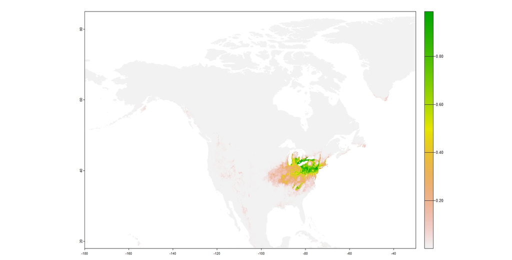

```r
# Wclim is the historical climatic conditions (1970-2000)
cor_pred_hist <- terra::predict(wclim, mod.best_cor_maxent, cores = cn - 1)

plot(cor_pred_hist)
points(occThin_cor, cex = 0.05)
```

We have made our first prediction of the **fundamental niche** of *M. coronaria*! But there are a few more things to consider before moving on.

First, is how confident can we be of these predictions? Using metrics like Area Under the Curve (AUC) and Continous Boyce Index can help us, however they have their own flaws, and so its important to **think critically** about the results of your predictions. Note that `ENMevaluate` and the MaxEnt algorithm automatically compute several indices, including separate indices calculated on the training data, and those calculated on the validation (testing) data.

- **AUC** is the visualization of the Relative Operating Characteristic (ROC) curve, which plots the False Positive Rate (1 - Specificity) vs. the True Positive Rate (Sensitivity). The closer the ROC curve follows the y-axis, the greater the area under the curve. In other words AUC is the sum of the area under the ROC curve.
  - An AUC value of **0.5** indicates the model cannot make predictions better than random.
  - An AUC value of **1** represents a perfect prediction.
  - As a general rule of thumb is a score over 0.7 is a moderately well performing model, and a score over 0.9 is excellent.
  - **NOTE:** Some authors points out that AUC can be misleading and should not be used as an ultimate method to evaluate model performance, and should be used in caution especially when comparing performance of different models.
  - Relevant reading: Lobo, J. M., Jiménez-Valverde, A., & Real, R. (2008). AUC: A misleading measure of the performance of predictive distribution models. Global Ecology and Biogeography, 17(2), 145–151. https://doi.org/10.1111/j.1466-8238.2007.00358.x.
- **CBI** is a plot of predicted-to-expected ratios, grouped into classes. The classes (or bins) are grouped by habitat suitability values. By default `ecospat.boyce` uses a moving window, where it forms classes by 1/10th of the suitability range. The Boyce Index is then calculated using a **Spearman rank correlation** metric between P/E scores and habitat suitability scores. What we expect to see is a steady increase in P/E with an increase suitability scores.
  - **NOTE:** It is important to plot the PE plot, and not just trust the correlation score at face value. If there is a sudden jump in P/E scores this can be suspicious.
  - Relevant reading: Hirzel, Alexandre H., Gwenaëlle Le Lay, Véronique Helfer, Christophe Randin, and Antoine Guisan. “Evaluating the ability of habitat suitability models to predict species presences.” Ecological modelling 199, no. 2 (2006): 142-152. https://doi.org/10.1016/j.ecolmodel.2006.05.017.

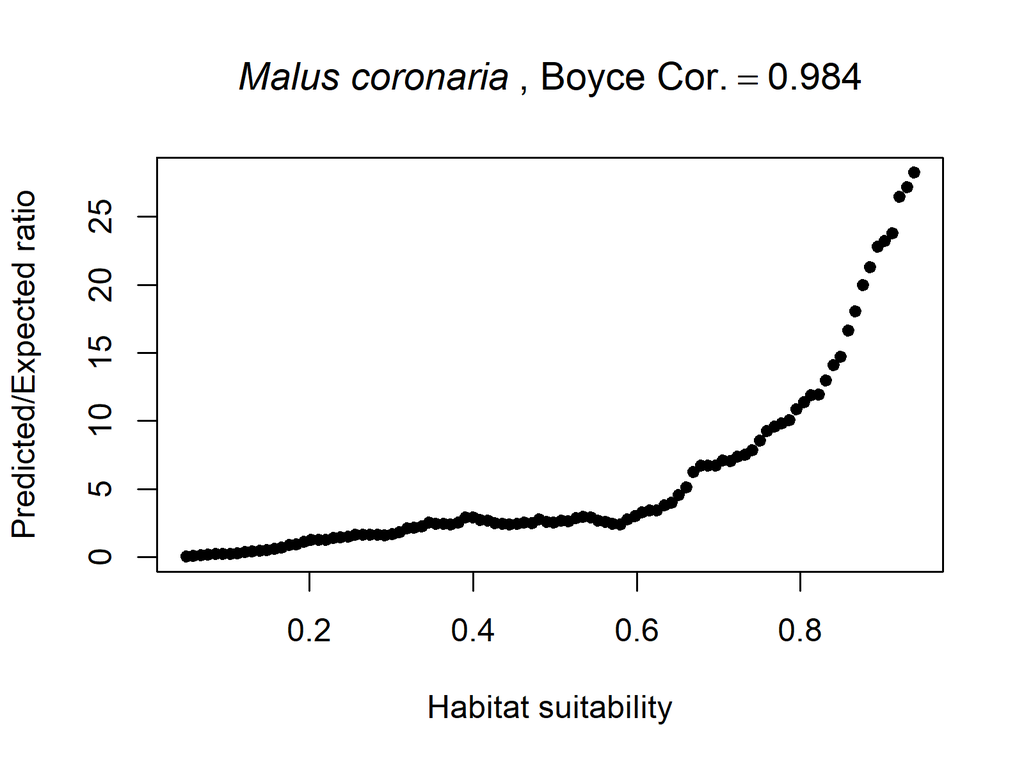

```r
# Evaluate predictions using Boyce Index
# the number of true presences should decline with suitability groups 100-91, 90-81, etc.
# First extract suitability values for the background and presence points, make sure to omit NA values
corPred_bg_val <- terra::extract(cor_pred_hist, bg_cor_coords)$lyr1 %>%
  na.omit()

corPred_val_na <- terra::extract(cor_pred_hist, occ_cor_coords)$lyr1 %>%
  na.omit()

# Evaluate predictions using Boyce Index
ecospat.boyce(fit = corPred_bg_val, # vector of predicted habitat suitability of bg points
                           obs = corPred_val, # vector of
                           nclass = 0,
                           PEplot = TRUE,
                           method = 'spearman')
```

Second, is it best to leave these suitability scores as a continuous gradient of habitat suitability? Myself (and many others) find maps with colour gradients illegible, or less informative at a glance. Some take the approach of creating a binary threshold, where habitat suitability is boolean. There are several methods to determine this binary threshold, which can be done using the `predicts` package. A flaw of this approach is it less tangible what these thresholds mean in lay terms, and biology is never as simple as YES/NO.

With that said (foreshadowing), these binary thresholds are very useful for completing gap analyses. Gap analyses are a natural next step after completing a SDM to understand how much of a species suitable habitat is covered by protected areas (PAs) so that we know how much of the specie’s habitat is protected.

```r
cor_pa <- predicts::pa_evaluate(p = occ_cor_coords_mat, a = bg_cor_coords_mat, model = cor_maxent, x = wclim_cor)
cor_threshold <- predicts::threshold(cor_pa)
cor_hist_habitat <- cor_pred_hist > cor_threshold$max_spec_sens #the threshold at which the sum of the sensitivity (true positive rate) and specificity (true negative rate) is highest
```

However, I think it is more practical to bin suitability scores into several **categories**. Lets say three categories: “High suitability”, “Moderate suitability” and “Low suitability”. These categories are **determined using qauntiles**, where suitability scores in the lowest percentiles can be considered to be lowly or moderately suitable, and higher scores considered to be of high suitability. In this case I use the 1st, 10th, and 50th percentile to classify these categories. This means that in the low habitat category we are only omitting 1% of predicted suitable habitat, compared to the 50th, were we are omitting 50% of predicted values. It is important to understand that this approach also has flaws, but typically the 10th percentile is considered a acceptable minimum threshold.

```r
corPred_val <- terra::extract(cor_pred_hist, occ_cor_coords)$lyr1
corPred_threshold_1 <- quantile(corPred_val, 0.01, na.rm = T) # Low suitability
corPred_threshold_10 <- quantile(corPred_val, 0.1, na.rm = T) # Moderate suitability
corPred_threshold_50 <- quantile(corPred_val, 0.5, na.rm = T) # High suitability

# Save suitability thresholds

setwd('../sdm_output/thresholds')
saveRDS(corPred_threshold_1, file = 'corPred_threshold_1.Rdata')
saveRDS(corPred_threshold_10, file = 'corPred_threshold_10.Rdata')
saveRDS(corPred_threshold_50, file = 'corPred_threshold_50.Rdata')
```

Now let’s visualize the results! As mentioned previously, we will tidy things up downstream to make publication quality plots. But, this is a great start!

[figure not shown]

```r
legend_labs <- c('Low Suitability', 'Moderate Suitability', 'High Suitability')
# brewer.pal(3, "YlOrBr") # Brewer palettes are helpful for mapping colour gradients
fill_cols <- c("#FFF7BC", "#FEC44F", "#D95F0E")

par(mar = c(5, 5, 5, 5))
terra::plot(cor_pred_hist > corPred_threshold_1, col = c('#E8E8E8', '#FFF7BC'), legend = F, xlim = c(-100, -50), ylim = c(30, 60), main = expression(atop(italic('Malus coronaria'), " Historical Suitability (1970-2000)")), background = 'lightskyblue1')
terra::plot(cor_pred_hist > corPred_threshold_10, col = c(NA, '#FEC44F'), add = T, legend = F)
terra::plot(cor_pred_hist > corPred_threshold_50, col = c(NA, '#D95F0E'), add = T, legend = F)
terra::plot(canUSMex_map, add = T)
points(occThin_cor, col = 'black', cex = 0.75, pch = 4)
legend(x = -75, y = 30, xpd = NA, inset = c(5, 0),
       title = 'Habitat Suitability',
       legend = legend_labs,
       fill = fill_cols)
```

Now we can move on to make predictions for the future climate scenarios. We will still use the **same threshold** values from the historical prediction to keep interpretation consistent. As always, make sure to save the predictions to save time when having to reload.

```r
# Future Climate predictions
# SSP 245
cor_pred_ssp245_30 <- terra::predict(ssp245_2030, mod.best_cor_maxent, cores = cn - 1)
cor_pred_ssp245_50 <- terra::predict(ssp245_2050, mod.best_cor_maxent, cores = cn - 1)
cor_pred_ssp245_70 <- terra::predict(ssp245_2070, mod.best_cor_maxent, cores = cn - 1)

# SSP585
cor_pred_ssp585_30 <- terra::predict(ssp585_2030, mod.best_cor_maxent, cores = cn - 1)
cor_pred_ssp585_50 <- terra::predict(ssp585_2050, mod.best_cor_maxent, cores = cn - 1)
cor_pred_ssp585_70 <- terra::predict(ssp585_2070, mod.best_cor_maxent, cores = cn - 1)

# Save M cor. SDM predictions
setwd('../sdm_output')
saveRDS(cor_pred_hist, file = 'cor_pred_hist.Rdata')

saveRDS(cor_pred_ssp245_30, file = 'cor_pred_ssp245_30.Rdata')
saveRDS(cor_pred_ssp245_50, file = 'cor_pred_ssp245_50.Rdata')
saveRDS(cor_pred_ssp245_70, file = 'cor_pred_ssp245_70.Rdata')

saveRDS(cor_pred_ssp585_30, file = 'cor_pred_ssp585_30.Rdata')
saveRDS(cor_pred_ssp585_50, file = 'cor_pred_ssp585_50.Rdata')
saveRDS(cor_pred_ssp585_70, file = 'cor_pred_ssp585_70.Rdata')
```

For the purposes of this tutorial I am only going to show results of one of the future climate predictions - SSP5-8.5 2020-2040 (the current tracking projection). I am using the same code as above for the historical suitability plot.

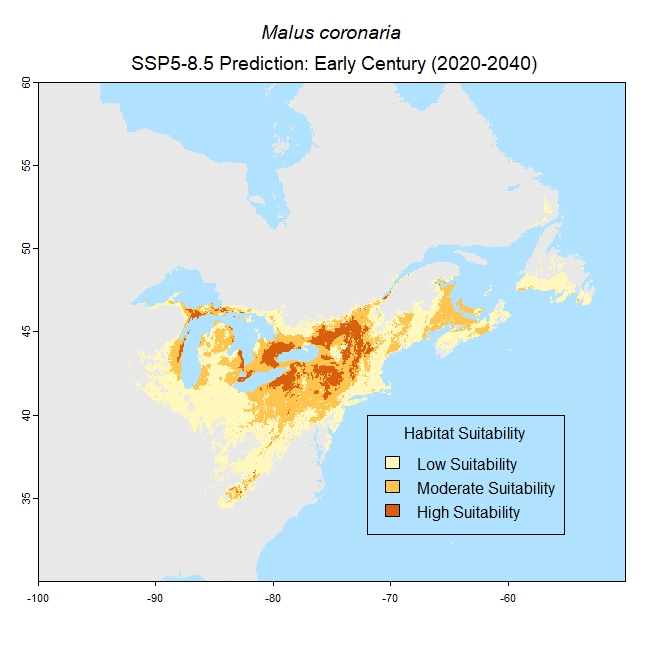

We can see a clear shift in the fundamental niche of *M. coronaria* northward. At the same time, it seems that the climate for *M. coronaria* will be favourable in Southern Ontario, as well as an expansion in Quebec and the Maritimes. Also pay attention to areas where fundamental habitat is being lost, especially in the US. Remember that these are simply predictions, that carry a lot of assumptions.

Now that we have made all our predictions and thresholds saved as `.Rdata` files lets move onto to tidying up plots to prepare them for a results section and publication! Also, if you have made it this far take a minute to appreciate just how much work has been accomplished.

## Publication Plots

One of my favourite, but most time consuming steps in a SDM workflow is producing figures. Designing a plot that effectively display results at the same time as being simple and aesthetically pleasing can take a lot of time and fine tuning. Not to mention that plotting spatial data can be difficult to say the least. With that said once you do nail a plot it is so rewarding!

It is important to note that there are several different approaches and packages that you can use to plot spatial vectors and rasters. One of the most popular packages is `ggplot2` (a.k.a ggplot), which is highly maintained and polished. It can be a bit of a learning curve, but once you get the hang of it it is THE way to make (most) plots. Not to mention there are endless packages that add functionality to `ggplot2` that can do a lot of cool things.

Now, with that said for the purposes of my publication and workflow I will be using the plotting functionality built into `terra`. As this is a newer package, there is less support and documentation in `ggplot2` but a package called `tidyterra` is well into development. Also, the `terra::plot` function builds off the base R graphics package, which can also have its advantages.

Now what exactly goes into a ‘publication quality’ plot. There is a long list of things that separates a good figure from a bad figure. I will go over a few decisions I have made, but I will not begin to scratch the surface. I **highly reccomend** taking a look at this YouTube video by the Riffomonas Project on creating publication quality figures (https://youtu.be/3y7pJYURspA?si=NsdrJU9MxnmNF6b_). The creator, Dr. Pat Schloss, is a microbiologist at the University of Michigan. He has an immense experience base in computational statistics, and a talent for simply explaining complex code. Checkout his catalog of videos and his website!! I take a lot of inspiration from his philosophy on open access statistics and coding - and certainly have learned a lot from him. Okay that is enough about my statics crush…

For a `terra` specific introduction to plotting checkout this great introduction to making simple maps with `terra` by my collaborator Dr. Tyler Smith, (https://plantarum.ca/2023/02/13/terra-maps/). He has recently updated the blog to be up to date with all the new `terra` functionality. Also checkout the rest of his blogs!

As always, let’s start by loading the raster layers and thresholds we saved from the SDM outputs.

**NOTE:** Due to the Lambert projection the x any y axes are now a projected coordinate system, and no longer standard geographic coordinates (Lat and Lon). Thus the axes limits must be set differently. IF you want to still plot lat/lon coordinates you need to project a graticule, which I will cover below.

Let’s begin…

```r
# Load occurrences and  raster/vectors
# Occurrence Points in SpatVectors
getwd()
setwd("../occ_data/")
occThin_cor <- readRDS(file = 'occThin_cor.Rdata') # M. coronaria
occThin_fus <- readRDS(file = 'occThin_fus.Rdata') # M. fusca

# Great Lakes shapefiles for making pretty maps
# Shape files downloaded from the USGS (https://www.sciencebase.gov/catalog/item/530f8a0ee4b0e7e46bd300dd)
great_lakes <- vect('C:/Users/terre/Documents/Acadia/Malus Project/maps/great lakes/combined great lakes/')
```

```r
# Canada/US Border for showing the international line. Gadm admin boundaries trace the entire country, vs this is just the border
# Much easier to see the SDM results along coastlines where tracing obscures the data
# Downloaded from  https://koordinates.com/layer/111012-canada-and-us-border/
can_us_border <- vect('C:/Users/terre/Documents/Acadia/Malus Project/maps/can_us border')
```

A small tweak I made to the vector was to remove the border lines drawn in the ocean on both coasts. This was purely for aesthetic reasons.Thankfully each segment of the vector is clearly named and easy to drop.

```r
can_us_border$SectionEng # access variable names of each segment
# Two line segments are in the water and are not needed in this case, lets remove them to make the maps look prettier
segments_to_remove <- c("Gulf of Maine", "Straits of Georgia and Juan de Fuca")
can_us_border <- can_us_border[!can_us_border$SectionEng %in% segments_to_remove, ]
```

Up until now all the maps produced above have been done using the World Geodectic System 1984 (a.k.a WGS84); which is a pseudo-Mercator projection that is the de facto standard for most web apps. With that said it is not very nice for producing figures of maps because it distorts shape and size of areas. So we will be using the **Lambert Conformal Conic projection**. This projection is ideal for mapping Canada and the US because its east-west orientation minimizes distortion across these large, elongated regions, providing a more accurate representation of geographic features and distances. It is also pretty much the standard projection in every Canadian geography textbook and it is also the official mapping projection of the Government of Canada.

For an introduction into projections and ‘Coordinate Reference Systems’ (CRS) visit in R https://rspatial.org/raster/spatial/6-crs.html.

```r
projLam <- "+proj=lcc +lat_1=49 +lat_2=77 +lat_0=49 +lon_0=-95 +x_0=0 +y_0=0 +datum=NAD83 +units=m +no_defs"
```

As I mentioned above, when creating a new projection in R other than the WGS84, you will need to produce graticules to show the latitude and longitude on the new coordinate system you are using. There is a function in `terra` to do this. I am not going to use it for my plots but it is good to know how to do it!

```r
# Gratitcules
g.cor <- terra::graticule(
  lon = seq(-110, -55, by = 10),  # Longitude from 130°W to 50°W
  lat = seq(30, 55, by = 10),     # Latitude from 25°N to 75°N
  crs = projLam
)
```

So now we need to get all of the spatial data we are going to project on the same coordinate system (The Lambert). This can take a few minutes to run!

```r
# Great lakes
great_lakes.lcc <- project(great_lakes, projLam)

# Can/US border
can_us_border.lcc <- project(can_us_border, projLam)

# Occurrences
occThin_cor.lcc <- project(occThin_cor, projLam)
occThin_fus.lcc <- project(occThin_fus, projLam)

# Habitat suitability
cor_pred_hist.lcc <- project(cor_pred_hist, projLam)

cor_pred_ssp245_30.lcc <- project(cor_pred_ssp245_30, projLam)
cor_pred_ssp245_50.lcc <- project(cor_pred_ssp245_50, projLam)
cor_pred_ssp245_70.lcc <- project(cor_pred_ssp245_70, projLam)

cor_pred_ssp585_30.lcc <- project(cor_pred_ssp585_30, projLam)
cor_pred_ssp585_50.lcc <- project(cor_pred_ssp585_50, projLam)
cor_pred_ssp585_70.lcc <- project(cor_pred_ssp585_70, projLam)
```

Ok we have done all the prep work we needed to do, now let’s make some figures!

```r
# We need three colours that clearly show the threshold categories
brewer.pal(3, "YlOrBr") # Brewer palettes are helpful for mapping colour gradients

legend_labs <- c('Low Suitability', 'Moderate Suitability', 'High Suitability')
fill_cols <- c("#FFF7BC", "#FEC44F", "#D95F0E")

# Then we need to determine some plot limits. Unfortunately it is a bit more tricky compared to the Mercator projection
# It can take some trial and error

cor.xlim <- c(-5*10^5, 3.1*10^6)
cor.ylim <- c(-2*10^6, 2*10^6)
```

I want to make a figure with multiple panels. You could absolutely do this in R, BUT sometimes the simplier solution can be easier. In this case I am going to make all the elements/panels of the figure and then edit it all together in PowerPoint! To start I am going to produce a legend.

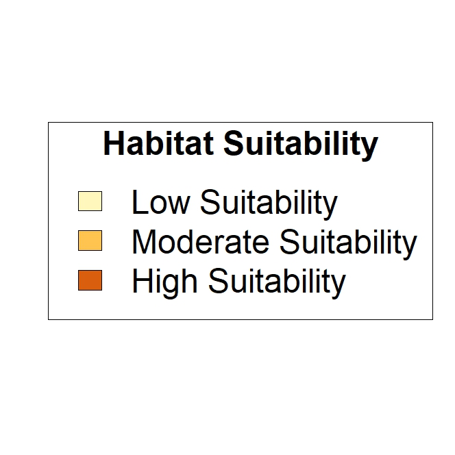

```r
# Plot a legend that can be saved on its own
plot(NULL ,xaxt='n',yaxt='n',bty='n',ylab='',xlab='', xlim=0:1, ylim=0:1)
legend('center', xpd = NA, title = c(as.expression(bquote(bold('Habitat Suitability')))), legend = legend_labs, fill = fill_cols, cex = 3)
```

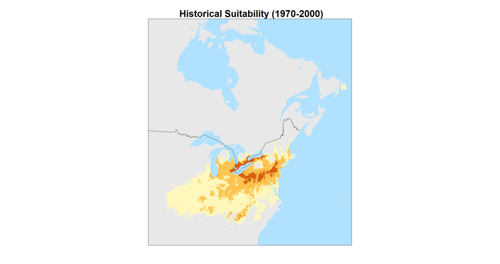

```r
# Plot historical distribution
terra::plot(cor_pred_hist.lcc > corPred_threshold_1, col = c('#E8E8E8', '#FFF7BC'),
            background = 'lightskyblue1',
            legend = F,
            xlim = cor.xlim, ylim = cor.ylim,
            main = " Historical Suitability (1970-2000)",
            cex.main = 3,
            axes = F,
            box = T,
            mar = c(5, 5, 5, 5))
terra::plot(cor_pred_hist.lcc > corPred_threshold_10, col = c(NA, '#FEC44F'), add = T, legend = F)
terra::plot(cor_pred_hist.lcc > corPred_threshold_50, col = c(NA, '#D95F0E'), add = T, legend = F)
terra::plot(can_us_border.lcc, add = T)
#terra::plot(g.cor, add = T, retro = T, col = '#999999',lab.lat = c(2,3,4), lab.lon = c(2,3,4,5), lab.cex = 1.5, mar = c(5,5,5,5), lab.loc = 1, off.lat = -0.01) # Code for adding a gratitcule to the plot.
```

Now I have repeated the plotting process for all time periods for both the SSPs. I took all those photos and went into PowerPoint and produced the following figure!

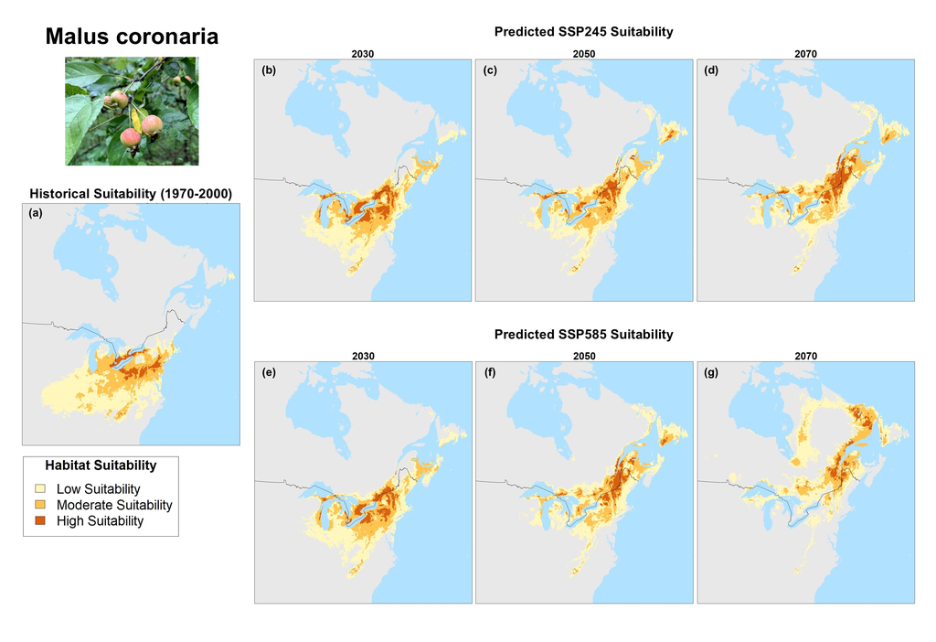

Now let’s break down some of the decisions I made when designing the map.

- I chose the sequential Brewer palettes as light colours stress lower values and darker greater values. This makes sense for habitat suitability going from low to high. The shades of brown are quick and easy to distinguish (but are not colour blind friendly). They are also soft hues that are <sub>aesthetic</sub>.
- The light grey background of North America is easily recognizable but it is not too dark to take the readers attention away from SDM results.
- As previously mentioned, in previous iterations I had administrative boundaries for each province/state but it was making the plots very busy. The question I asked myself is, is the cluster worth the information being presented - or is it even relevant at all. No, not really! BUT it is important to show the international border!
- The ocean could have remained white, but it is a bit more clear what is water if we make it blue. The light blue matches the soft browns and grey. It also distinguishes the background of the map from the rest of the figure.
- The arrangement of the historical plot and then the SSPs which it creates a sensible hierarchy with each year as a column and row as a different SSP. It is more natural to read left to right, following the time progression then to compare up and down.
- The legend is large and clear.
- The species is in the top left to be the first thing the reader sees, with a accompanying picture that draws the reader in and reminds them what species they are looking at. The same picture is used in a previous figure introducing the species to create continuity.
- Each panel is labeled with letters so that they can be easily referenced in-text.
- Overall the plot is minimal, nothing is excessive, and the whole plot is soft and easy to look at. (At least in my humble opinion).

## Gap Analysis

The natural next step after completing a SDM is to complete a gap analysis.

A gap analysis is a method in conservation biology to assess the effectiveness of existing protected areas (PAs) and ex situ collections in conserving biodiversity. The analysis can identify where the species of interest (or ecosystem) is protected or not, and to what extent they are represented within those protected areas. There are many different approaches and software for completing this analysis, but to as we have come this far we will be sticking with R. Dan Carver et al. 2021 (https://nsojournals.onlinelibrary.wiley.com/doi/full/10.1111/ecog.05430) published a great package for completing gap analyses in R, but there are now several deprecated dependencies which has made the package inoperable. With that said we can still use their equations to complete the analysis ourselves.

Unfortunately for the *Malus* species I am working with there are simply not enough ex situ data in existence in Canada to complete it. We do however thankfully have enough data to do an **in situ analysis**.

```r
library(tidyverse) # Grammar and data management
library(terra) # Spatial Data package
library(geodata) # basemaps
library(ggpubr) # arrange ggplot figures

# The following gap analysis is referencing Carver et al. (2021)
# https://nsojournals.onlinelibrary.wiley.com/doi/full/10.1111/ecog.05430

# For the purposes of the analysis we are restricting the study area to just Canada
```

To begin we need to get spatial data of the protected areas in Canada. The Canadian government releases all their protected and conserved areas - this includes terrestrial and marine areas, as well as effective area-based conservation measures (OECM). In this analysis I am only considering PAs, although for your purposes you may want to consider including OECMs. Link to Canadian Protected and Conserved Areas Database (CPCAD) https://www.canada.ca/en/environment-climate-change/services/national-wildlife-areas/protected-conserved-areas-database.html.

Read more about Canadian OECMs here: https://www.canada.ca/en/environment-climate-change/services/nature-legacy/other-effective-area-based-measures.html.

```r
# Protected Area and OECM data from
# Download .kmz file and vectorize using terra

pro_area <- terra::vect("C:/Users/terre/Documents/Acadia/Malus Project/maps/canada_pa/ProtectedConservedArea_2023/ProtectedConservedArea_2023/ProtectedConservedArea_2023.gdb")
pro_area <- pro_area[pro_area$BIOME == 'T'] # filter only the terrestrial protected areas and OECMs
pro_area <- pro_area[pro_area$PA_OECM_DF == '1'] # filter only protected areas (remove OECMs)
pro_area <- project(pro_area, 'WGS84') # project the PAs to be the same CRS as the SDM layers
```

**NOTE:** The CPCAD data uses a different projection than what we saved our spatial data as so make sure to change the projection.

Here we can see all the terrestrial protected areas in Canada as of Sept. 2024. Note that this does not include OECMs.

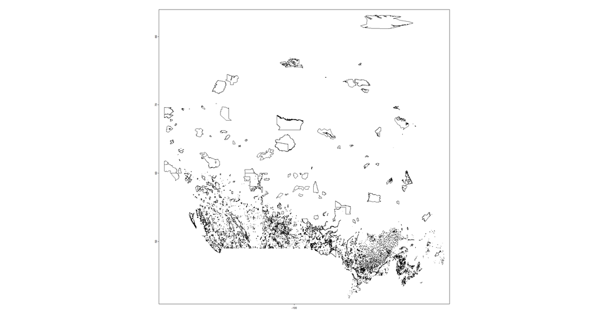

Now let’s load in all the necessary SDM layers, species occurrences and base maps.

```r
# I am using the complete suitability rasters and thresholds separately
# Could also load pre-categorized layers as well

# M. coronaria
getwd()
setwd('../sdm_output/')

cor_pred_hist <- readRDS(file = 'cor_pred_hist.Rdata')

cor_pred_ssp245_30 <- readRDS(file = 'cor_pred_ssp245_30.Rdata')
cor_pred_ssp245_50 <- readRDS(file = 'cor_pred_ssp245_50.Rdata')
cor_pred_ssp245_70 <- readRDS(file = 'cor_pred_ssp245_70.Rdata')

cor_pred_ssp585_30 <- readRDS(file = 'cor_pred_ssp585_30.Rdata')
cor_pred_ssp585_50 <- readRDS(file = 'cor_pred_ssp585_50.Rdata')
cor_pred_ssp585_70 <- readRDS(file = 'cor_pred_ssp585_70.Rdata')

# Thresholds
# M. coronaria
setwd('../sdm_output/thresholds')
corPred_threshold_1 <- readRDS(file = 'corPred_threshold_1.Rdata')
corPred_threshold_10 <- readRDS(file = 'corPred_threshold_10.Rdata')
corPred_threshold_50 <- readRDS(file = 'corPred_threshold_50.Rdata')

# Load a Canada Admin boundary
getwd()
setwd('../occ_data')
ca_bound <- gadm(country = 'CA', level = 0, resolution = 1,
               path = '../occ_data/base_maps')
```

**NOTE:** I am following Carver et al., 2021. I will not be explaining in very much detail what each metric represents so go checkout the paper!

**ANOTHER NOTE:** One major difference in this workflow to Carver et al., 2021 is that I am using the projected SSPs to look at the future scores of these metrics - if the PAs were to stay the same as they are today.

Now the first gap analysis statistic we want to calculate is the **sampling representativeness score in situ (SRSin)**. To do this we will need to crop and mask the predicted SDM layers to Canada’s borders. Then we will take the product of that and crop and mask it to only the protected areas (PAs).

I will note that the way I am coding it here is not likely the most efficient or clean - but it will get the job done! Let’s hope Dan can get get the GapAnalysisR package back to complete strength. But this workflow does serve as an example on how to manually complete these calculations on your own!

```r
# Mask and crop SDM layer to Canada

# M. coronaria
# Historical
can_cor_pred_hist <- crop(cor_pred_hist, ca_bound, mask = T)

# SSP245
can_cor_pred_ssp245_30 <- crop(cor_pred_ssp245_30, ca_bound, mask = T)
can_cor_pred_ssp245_50 <- crop(cor_pred_ssp245_50, ca_bound, mask = T)
can_cor_pred_ssp245_70 <- crop(cor_pred_ssp245_70, ca_bound, mask = T)

# SSP585
can_cor_pred_ssp585_30 <- crop(cor_pred_ssp585_30, ca_bound, mask = T)
can_cor_pred_ssp585_50 <- crop(cor_pred_ssp585_50, ca_bound, mask = T)
can_cor_pred_ssp585_70 <- crop(cor_pred_ssp585_70, ca_bound, mask = T)

# Mask Suitable Habitat rasters to the PA polygons

#M. coronaria
#Historical
pa_cor_pred_hist <- crop(can_cor_pred_hist, pro_area, mask = T)

# SSP245
pa_cor_pred_ssp245_30 <- crop(cor_pred_ssp245_30, pro_area, mask = T)
pa_cor_pred_ssp245_50 <- crop(cor_pred_ssp245_50, pro_area, mask = T)
pa_cor_pred_ssp245_70 <- crop(cor_pred_ssp245_70, pro_area, mask = T)

# SSP585
pa_cor_pred_ssp585_30 <- crop(cor_pred_ssp585_30, pro_area, mask = T)
pa_cor_pred_ssp585_50 <- crop(cor_pred_ssp585_50, pro_area, mask = T)
pa_cor_pred_ssp585_70 <- crop(cor_pred_ssp585_70, pro_area, mask = T)
```

So now that the layers are properly cropped and masked to the only the areas we want to consider, we need to extract all the true presences. As you will remember from above these are the cases where occurrences fall within an area that is predicted as suitable. Then we will do the same for all the true positive occurences that fall within PAs.

```r
# Extract occurrence points that fall within the SDM prediction
# M. coronaria
# Historical
index_cor_pos_hist_low <- extract(can_cor_pred_hist > corPred_threshold_1, occThin_cor) %>% filter(lyr1 == T) # filter only the true cases # filter only the true cases
index_cor_pos_hist_mod <- extract(can_cor_pred_hist > corPred_threshold_10, occThin_cor) %>% filter(lyr1 == T)
index_cor_pos_hist_high <- extract(can_cor_pred_hist > corPred_threshold_50, occThin_cor) %>% filter(lyr1 == T)

# SSP245
index_cor_pos_ssp245_30_low <- extract(can_cor_pred_ssp245_30 > corPred_threshold_1, occThin_cor) %>% filter(lyr1 == T) # filter only the true cases # filter only the true cases
index_cor_pos_ssp245_30_mod <- extract(can_cor_pred_ssp245_30 > corPred_threshold_10, occThin_cor) %>% filter(lyr1 == T)
index_cor_pos_ssp245_30_high <- extract(can_cor_pred_ssp245_30 > corPred_threshold_50, occThin_cor) %>% filter(lyr1 == T)

index_cor_pos_ssp245_50_low <- extract(can_cor_pred_ssp245_50 > corPred_threshold_1, occThin_cor) %>% filter(lyr1 == T) # filter only the true cases # filter only the true cases
index_cor_pos_ssp245_50_mod <- extract(can_cor_pred_ssp245_50 > corPred_threshold_10, occThin_cor) %>% filter(lyr1 == T)
index_cor_pos_ssp245_50_high <- extract(can_cor_pred_ssp245_50 > corPred_threshold_50, occThin_cor) %>% filter(lyr1 == T)

index_cor_pos_ssp245_70_low <- extract(can_cor_pred_ssp245_70 > corPred_threshold_1, occThin_cor) %>% filter(lyr1 == T) # filter only the true cases # filter only the true cases
index_cor_pos_ssp245_70_mod <- extract(can_cor_pred_ssp245_70 > corPred_threshold_10, occThin_cor) %>% filter(lyr1 == T)
index_cor_pos_ssp245_70_high <- extract(can_cor_pred_ssp245_70 > corPred_threshold_50, occThin_cor) %>% filter(lyr1 == T)

# SSP585
index_cor_pos_ssp585_30_low <- extract(can_cor_pred_ssp585_30 > corPred_threshold_1, occThin_cor) %>% filter(lyr1 == T) # filter only the true cases # filter only the true cases
index_cor_pos_ssp585_30_mod <- extract(can_cor_pred_ssp585_30 > corPred_threshold_10, occThin_cor) %>% filter(lyr1 == T)
index_cor_pos_ssp585_30_high <- extract(can_cor_pred_ssp585_30 > corPred_threshold_50, occThin_cor) %>% filter(lyr1 == T)

index_cor_pos_ssp585_50_low <- extract(can_cor_pred_ssp585_50 > corPred_threshold_1, occThin_cor) %>% filter(lyr1 == T) # filter only the true cases # filter only the true cases
index_cor_pos_ssp585_50_mod <- extract(can_cor_pred_ssp585_50 > corPred_threshold_10, occThin_cor) %>% filter(lyr1 == T)
index_cor_pos_ssp585_50_high <- extract(can_cor_pred_ssp585_50 > corPred_threshold_50, occThin_cor) %>% filter(lyr1 == T)

index_cor_pos_ssp585_70_low <- extract(can_cor_pred_ssp585_70 > corPred_threshold_1, occThin_cor) %>% filter(lyr1 == T) # filter only the true cases # filter only the true cases
index_cor_pos_ssp585_70_mod <- extract(can_cor_pred_ssp585_70 > corPred_threshold_10, occThin_cor) %>% filter(lyr1 == T)
index_cor_pos_ssp585_70_high <- extract(can_cor_pred_ssp585_70 > corPred_threshold_50, occThin_cor) %>% filter(lyr1 == T)


# Extract that occurrences that fall within the PAs
# M. coronaria
# Historical
index_pa_cor_pos_hist_low <- extract(pa_cor_pred_hist > corPred_threshold_1, occThin_cor) %>% filter(lyr1 == T) # filter only the true cases # filter only the true cases
index_pa_cor_pos_hist_mod <- extract(pa_cor_pred_hist > corPred_threshold_10, occThin_cor) %>% filter(lyr1 == T)
index_pa_cor_pos_hist_high <- extract(pa_cor_pred_hist > corPred_threshold_50, occThin_cor) %>% filter(lyr1 == T)

# SSP245
index_pa_cor_pos_ssp245_30_low <- extract(pa_cor_pred_ssp245_30 > corPred_threshold_1, occThin_cor) %>% filter(lyr1 == T) # filter only the true cases # filter only the true cases
index_pa_cor_pos_ssp245_30_mod <- extract(pa_cor_pred_ssp245_30 > corPred_threshold_10, occThin_cor) %>% filter(lyr1 == T)
index_pa_cor_pos_ssp245_30_high <- extract(pa_cor_pred_ssp245_30 > corPred_threshold_50, occThin_cor) %>% filter(lyr1 == T)

index_pa_cor_pos_ssp245_50_low <- extract(pa_cor_pred_ssp245_50 > corPred_threshold_1, occThin_cor) %>% filter(lyr1 == T) # filter only the true cases # filter only the true cases
index_pa_cor_pos_ssp245_50_mod <- extract(pa_cor_pred_ssp245_50 > corPred_threshold_10, occThin_cor) %>% filter(lyr1 == T)
index_pa_cor_pos_ssp245_50_high <- extract(pa_cor_pred_ssp245_50 > corPred_threshold_50, occThin_cor) %>% filter(lyr1 == T)

index_pa_cor_pos_ssp245_70_low <- extract(pa_cor_pred_ssp245_70 > corPred_threshold_1, occThin_cor) %>% filter(lyr1 == T) # filter only the true cases # filter only the true cases
index_pa_cor_pos_ssp245_70_mod <- extract(pa_cor_pred_ssp245_70 > corPred_threshold_10, occThin_cor) %>% filter(lyr1 == T)
index_pa_cor_pos_ssp245_70_high <- extract(pa_cor_pred_ssp245_70 > corPred_threshold_50, occThin_cor) %>% filter(lyr1 == T)

# SSP585
index_pa_cor_pos_ssp585_30_low <- extract(pa_cor_pred_ssp585_30 > corPred_threshold_1, occThin_cor) %>% filter(lyr1 == T) # filter only the true cases # filter only the true cases
index_pa_cor_pos_ssp585_30_mod <- extract(pa_cor_pred_ssp585_30 > corPred_threshold_10, occThin_cor) %>% filter(lyr1 == T)
index_pa_cor_pos_ssp585_30_high <- extract(pa_cor_pred_ssp585_30 > corPred_threshold_50, occThin_cor) %>% filter(lyr1 == T)

index_pa_cor_pos_ssp585_50_low <- extract(pa_cor_pred_ssp585_50 > corPred_threshold_1, occThin_cor) %>% filter(lyr1 == T) # filter only the true cases # filter only the true cases
index_pa_cor_pos_ssp585_50_mod <- extract(pa_cor_pred_ssp585_50 > corPred_threshold_10, occThin_cor) %>% filter(lyr1 == T)
index_pa_cor_pos_ssp585_50_high <- extract(pa_cor_pred_ssp585_50 > corPred_threshold_50, occThin_cor) %>% filter(lyr1 == T)

index_pa_cor_pos_ssp585_70_low <- extract(pa_cor_pred_ssp585_70 > corPred_threshold_1, occThin_cor) %>% filter(lyr1 == T) # filter only the true cases # filter only the true cases
index_pa_cor_pos_ssp585_70_mod <- extract(pa_cor_pred_ssp585_70 > corPred_threshold_10, occThin_cor) %>% filter(lyr1 == T)
index_pa_cor_pos_ssp585_70_high <- extract(pa_cor_pred_ssp585_70 > corPred_threshold_50, occThin_cor) %>% filter(lyr1 == T)
```

**Note:** We need to filter the layers to only include the ‘lyr1’ value equal to T (or True).

Now we have a list of all the true positive occurrences for the entire predicted suitable area in Canada, and those cases that fall within PAs in Canada. So now we want to count how of each there are and calculate the **SRSin** metric.

```r
# return count of the number of occurrences
# positive occurrences (overall)
# list of obj names from above
occ_names <- list(
  index_cor_pos_hist_low,
  index_cor_pos_hist_mod,
  index_cor_pos_hist_high,
  index_cor_pos_ssp245_30_low,
  index_cor_pos_ssp245_30_mod,
  index_cor_pos_ssp245_30_high,
  index_cor_pos_ssp245_50_low,
  index_cor_pos_ssp245_50_mod,
  index_cor_pos_ssp245_50_high,
  index_cor_pos_ssp245_70_low,
  index_cor_pos_ssp245_70_mod,
  index_cor_pos_ssp245_70_high,
  index_cor_pos_ssp585_30_low,
  index_cor_pos_ssp585_30_mod,
  index_cor_pos_ssp585_30_high,
  index_cor_pos_ssp585_50_low,
  index_cor_pos_ssp585_50_mod,
  index_cor_pos_ssp585_50_high,
  index_cor_pos_ssp585_70_low,
  index_cor_pos_ssp585_70_mod,
  index_cor_pos_ssp585_70_high)

# return counts in a vector
SRSin_occ <- occ_names %>%
  lapply(., nrow) %>%
  unlist()

# positive occurrences within PAs
pa_names <- list(
  index_pa_cor_pos_hist_low,
  index_pa_cor_pos_hist_mod,
  index_pa_cor_pos_hist_high,
  index_pa_cor_pos_ssp245_30_low,
  index_pa_cor_pos_ssp245_30_mod,
  index_pa_cor_pos_ssp245_30_high,
  index_pa_cor_pos_ssp245_50_low,
  index_pa_cor_pos_ssp245_50_mod,
  index_pa_cor_pos_ssp245_50_high,
  index_pa_cor_pos_ssp245_70_low,
  index_pa_cor_pos_ssp245_70_mod,
  index_pa_cor_pos_ssp245_70_high,
  index_pa_cor_pos_ssp585_30_low,
  index_pa_cor_pos_ssp585_30_mod,
  index_pa_cor_pos_ssp585_30_high,
  index_pa_cor_pos_ssp585_50_low,
  index_pa_cor_pos_ssp585_50_mod,
  index_pa_cor_pos_ssp585_50_high,
  index_pa_cor_pos_ssp585_70_low,
  index_pa_cor_pos_ssp585_70_mod,
  index_pa_cor_pos_ssp585_70_high)

# return counts in a vector
SRSin_pa <- pa_names %>%
            lapply(., nrow) %>%
            unlist()

# Calculate SRSin score

SRSin_score <- ((SRSin_pa/SRSin_occ) * 100) %>% replace_na(., 0) # some values are NAs as there are 0 in the denominator
```

**NOTE:** Some NA values are produced in the SRSin calculation, as there are cases where in the future SDM predictions (total area) there is no suitable area covering where occurrence data is found. So we take those cases to equal zero here.

Now we want to create a dataframe to store all the results in. We also should be thinking about how we can make it easy on ourselves to plot this data in `ggplot2` downstream.

```r
in_situ <- data.frame(
  species = c(rep('Malus coronaria', times = 21)),
  ssp = c(rep('historical', times = 3), rep(245, times = 9), rep(585, times = 9)),
  suitability = rep(c('low', 'moderate', 'high'), times = 7),
  period = c(rep(2000, times = 3), rep(2030, times = 3), rep(2050, times = 3), rep(2070, times = 3),
             rep(2030, times = 3), rep(2050, times = 3), rep(2070, times = 3)),
  SRSin = SRSin_score
)

print(in_situ)
```

Now lets calculate the **geographical representativeness score in situ (GRSin)** metric. This is a score of the total area of PAs that is suitable habitat divided by all the area that the SDM predicted was suitable habitat. To do that we need to begin by calculating the area of the total suitable habitat and that of the protected area containing suitable habitat.

```r
# Overal suitable area
# create a list of rasters to calculate total suitable area for each threshold, time period and SSP

suitable_area_rasts <- list(
can_cor_pred_hist > corPred_threshold_1,
can_cor_pred_hist > corPred_threshold_10,
can_cor_pred_hist > corPred_threshold_50,
can_cor_pred_ssp245_30 > corPred_threshold_1,
can_cor_pred_ssp245_30 > corPred_threshold_10,
can_cor_pred_ssp245_30 > corPred_threshold_50,
can_cor_pred_ssp245_50 > corPred_threshold_1,
can_cor_pred_ssp245_50 > corPred_threshold_10,
can_cor_pred_ssp245_50 > corPred_threshold_50,
can_cor_pred_ssp245_70 > corPred_threshold_1,
can_cor_pred_ssp245_70 > corPred_threshold_10,
can_cor_pred_ssp245_70 > corPred_threshold_50,
can_cor_pred_ssp585_30 > corPred_threshold_1,
can_cor_pred_ssp585_30 > corPred_threshold_10,
can_cor_pred_ssp585_30 > corPred_threshold_50,
can_cor_pred_ssp585_50 > corPred_threshold_1,
can_cor_pred_ssp585_50 > corPred_threshold_10,
can_cor_pred_ssp585_50 > corPred_threshold_50,
can_cor_pred_ssp585_70 > corPred_threshold_1,
can_cor_pred_ssp585_70 > corPred_threshold_10,
can_cor_pred_ssp585_70 > corPred_threshold_50)

# the following will return a vector of the total suitable habitat in km^2
# lapply allows you to iterate functions over a list
# terra::extract calculates the total area of a raster
# I then initiate a anaymous function to create a dataframe of the listed values so that
# they can be filtered such that only TRUE suitable areas (value = 1) are selected
# and then the area is returned using pull (extracts single column) for all cases that match value = 1
# finally I unlist the temporary df so that the area is returned in a vector

total_area <- lapply(suitable_area_rasts, terra::expanse, byValue = T, unit = 'km') %>%
  lapply(., function(df) {
    df %>% filter(value == 1) %>% pull(area)
  }) %>%
  unlist()
```

And we simply repeat what’s above for protected areas.

```r
pa_area_rasts <- list(
  pa_cor_pred_hist > corPred_threshold_1,
  pa_cor_pred_hist > corPred_threshold_10,
  pa_cor_pred_hist > corPred_threshold_50,
  pa_cor_pred_ssp245_30 > corPred_threshold_1,
  pa_cor_pred_ssp245_30 > corPred_threshold_10,
  pa_cor_pred_ssp245_30 > corPred_threshold_50,
  pa_cor_pred_ssp245_50 > corPred_threshold_1,
  pa_cor_pred_ssp245_50 > corPred_threshold_10,
  pa_cor_pred_ssp245_50 > corPred_threshold_50,
  pa_cor_pred_ssp245_70 > corPred_threshold_1,
  pa_cor_pred_ssp245_70 > corPred_threshold_10,
  pa_cor_pred_ssp245_70 > corPred_threshold_50,
  pa_cor_pred_ssp585_30 > corPred_threshold_1,
  pa_cor_pred_ssp585_30 > corPred_threshold_10,
  pa_cor_pred_ssp585_30 > corPred_threshold_50,
  pa_cor_pred_ssp585_50 > corPred_threshold_1,
  pa_cor_pred_ssp585_50 > corPred_threshold_10,
  pa_cor_pred_ssp585_50 > corPred_threshold_50,
  pa_cor_pred_ssp585_70 > corPred_threshold_1,
  pa_cor_pred_ssp585_70 > corPred_threshold_10,
  pa_cor_pred_ssp585_70 > corPred_threshold_50)

pa_area <- lapply(pa_area_rasts, terra::expanse, byValue = T, unit = 'km') %>%
  lapply(., function(df) {
    df %>% filter(value == 1) %>% pull(area)
  }) %>%
  unlist()
```

Now we should have everything we need to make the **GRSin** calculation.

```r
# calculate the GRSin score
GRSin_score <- (pa_area/total_area) * 100

# add it to the data frame from above

in_situ <- in_situ %>% mutate(GRSin = GRSin_score)
```

The next metric is the calculation of the **ecological representativeness score in situ (ERSin)**.

**NOTE:** another deviation from Carver et al., 2021 is we will be using a different set of ecoregions. They are using ecoregion data from the Nature Conservacy Geospatial Atlas (https://geospatial.tnc.org/datasets/7b7fb9d945544d41b3e7a91494c42930_0). Wereas we will be using the ecoregion data from the background analysis script from the EPA (https://www.epa.gov/eco-research/ecoregions-north-america>), sticking with level II as used above.

```r
# Download NA Ecoregion shapefile from: https://www.epa.gov/eco-research/ecoregions-north-america
# Load shapefile from local files
ecoNA <- vect(x = "C:/Users/terre/Documents/Acadia/Malus Project/maps/eco regions/na_cec_eco_l2/", layer = 'NA_CEC_Eco_Level2')
ecoNA <- project(ecoNA, 'WGS84') # project ecoregion vector to same coords ref as basemap
```

So now lets take our list of rasters that we made for the GRSin calculation and reuse it here. We want to convert all the polygons in the suitable habitat rasters to points, so that we can extract the names of the eco regions from the eco region vector. To do that we will use the `lapply()` function to convert all the rasters to points, while also defining an anonymous function to only select the ‘true’ layer. Remember we only want the points of the TRUE cases where habitat is in fact suitable.

```r
# suitable habitat eco regions
suitable_area_points <- lapply(suitable_area_rasts, terra::as.points) %>%
  lapply(., function (x) {
    x[x$lyr1 == 1, ]
  })

# protected area ecoregions
pa_area_points <- lapply(pa_area_rasts, terra::as.points) %>%
        lapply(., function (x) {
          x[x$lyr1 == 1, ]
        })
```

**IMPORTANT NOTE** This next step is **computationally expensive** and will take several hours to complete. In my case it took a total of 17 hours to complete this chunk. It is worth noting that this can be reduced if you use less input spatial points (ie. the SDM rasters converted to points), if you were to use fewer suitability thresholds, fewer time periods and/or fewer SSPs.

```r
start <- Sys.time()
suitable_area_eco <- lapply(suitable_area_points, function(point) {
  terra::extract(x = ecoNA, y = point)
})
print( Sys.time() - start )

# took 12.93733 hours to complete

start <- Sys.time()
pa_area_eco <- lapply(pa_area_points, function(point) {
  terra::extract(x = ecoNA, y = point)
})
print( Sys.time() - start )

# took 3.679289 hours to complete
```

We especially want to save these intermidate objects after the scripts are complete

```r
# SAVE/LOAD eco regiion results
getwd()
setwd('../gap_analysis')
saveRDS(suitable_area_eco, file = 'suitable_area_eco.Rdata')
saveRDS(pa_area_eco, file = 'pa_area_eco.Rdata')

suitable_area_eco <- readRDS(file = 'suitable_area_eco.Rdata')
pa_area_eco <- readRDS('pa_area_eco.Rdata')
```

So now we want to filter the data so that we can find out the number of ecoregions repesented in each layer supplied.

```r
# return unique names and number of eco regions

suit_area_eco_num <- suitable_area_eco %>%
                      bind_rows(.id = 'source_list') %>% # bind the lists of lists together
                      unnest(cols = c(NA_L2NAME)) %>% # unnest the lists into columns of a dataframe
                      distinct(source_list, NA_L2CODE) %>% # return only the unique eco regions grouped by source list (aka the raster layers)
                      filter(!NA_L2CODE %in% c(NA, '0.0')) %>% # remove NA and 0.0 (water) valyes
                      add_count(source_list, name = 'num_eco') %>%  # count the number of nrow for each source list (or number of eco regions)
                      distinct(source_list, num_eco) # return the number of eco regions per source list



pa_area_eco_num <- pa_area_eco %>%
                    bind_rows(.id = 'source_list') %>% # bind the lists of lists together
                    unnest(cols = c(NA_L2NAME)) %>% # unnest the lists into columns of a dataframe
                    distinct(source_list, NA_L2CODE) %>% # return only the unique eco regions grouped by source list (aka the raster layers)
                    filter(!NA_L2CODE %in% c(NA, '0.0')) %>% # remove NA and 0.0 (water) valyes
                    add_count(source_list, name = 'num_eco') %>% # count the number of nrow for each source list (or number of eco regions)
                    distinct(source_list, num_eco) # return the number of eco regions per source list
```

And now we should have all the numbers needed to calculate the **ERSin** metric.

```r
# Now calculate the ERSin score
ERSin_score <- (pa_area_eco_num$num_eco / suit_area_eco_num$num_eco) * 100

# Mutate the ERSin score to the master df
in_situ <- in_situ %>% mutate(ERSin = ERSin_score)
```

So now that we have the SRSin, GRSin and ERSin scores, we can calculate the The **final conservation score in situ (FCSin)**. This is a very simple calculation to do in R.

```r
# Calculate the final conservation score for in situ conservation

in_situ <- in_situ %>% mutate(FCSin = ((SRSin + GRSin + ERSin)/3))
```

Now we have all the calculations complete it is time to visualize it! I am only going to show one example plot - so just replicate it for all the data!

```r
# bar plots
fill_cols <- c("#EDF8B1", "#7FCDBB", "#2C7FB8")

# M. coronaria
cor_srs_combined <- in_situ %>% filter(species == 'Malus coronaria' & suitability == 'high') %>%
  ggplot(aes(x = period, y = SRSin, fill = ssp)) +
  geom_col(position = position_dodge()) +
  scale_x_continuous(limits = c(1990, 2080),
                     breaks = c(2000, 2030, 2050, 2070),
                     labels = c("Historical", 2030, 2050, 2070)) +
  scale_y_continuous(limits = c(0, 105),
                     breaks = c(0, 20, 40, 60, 80, 100),
                     expand = c(0,0)) +
  theme_classic() +
  scale_fill_manual(values = fill_cols,
                    breaks = c('historical', '245', '585'),
                    labels = c('Historical', 'SSP245', 'SSP585')) +
  theme(text = element_text(size = 30, colour = 'black'),
        axis.text = element_text(colour = 'black'),
        axis.title.x=element_blank(),
        legend.title = element_blank())

# ditto
# arrange plots using <ggpubr>

ggarrange(cor_srs_combined, cor_grs_combined, cor_ers_combined, cor_fcs_combined,
          nrow = 1, ncol = 4,
          legend = "top",
          common.legend = T)
```

And this is the result!

[figure not shown]